# This notebook is divided into two.

# In the first part I will show how I learned the material

# And in the second part I will solve the assignment itself

# There will be a large header indicating where it is

I will try to explain here about a contest that checks if there were sarcastic sentences in a certain text.

Basically a classification.

Pay attention ! At first, Gayson's data worked for me, but suddenly there were glitches. All the comments are as if the data was full! I only took part of them for the purpose of teaching

# token the senteces

```python
from tensorflow.keras.preprocessing.text import Tokenizer

sentences = ['I love my dog', 'I love my cat']
tokenizer = Tokenizer(num_words = 100) # max words to keep
tokenizer.fit_on_texts(sentences)# go all over the sentences and fit them
word_index = tokenizer.word_index
print(word_index)
sequences = tokenizer.texts_to_sequences(sentences) # מקבל את האינדקסים של המילים לפי הסדר במשפטי קלט
print("\n",sequences)
```

```
{'i': 1, 'love': 2, 'my': 3, 'dog': 4, 'cat': 5}

 [[1, 2, 3, 4], [1, 2, 3, 5]]
```

```python
from tensorflow.keras.preprocessing.text import Tokenizer
from tensorflow.keras.preprocessing.sequence import pad_sequences # added

sentences = ['I love my dog',
             'I love my cat',
             'You love my dog',
             'Do you think my dog is amazing?']

tokenizer = Tokenizer(num_words = 100,oov_token = "<OOV>") # changed
tokenizer.fit_on_texts(sentences)
word_index1 = tokenizer.word_index

sequences1 = tokenizer.texts_to_sequences(sentences)

padded1 = pad_sequences(sequences)

print(word_index1)
print("\n")
print(sequences)
print("\n")
print(padded1)
print("\n\n")
print("you can see the matrix that start with zeros .. \nits becuse the longest sentence is 7 words (Do you think my dog is amazing?\n\n")
print("and the matrix need to be in the same size , so it put zeros.(padding) \n\n ")
print("if we want to change that we gonna use the code padded = pad_sequences(sequences,padding='post').\n\n")
print("but also i can make sure that she size of each row gonna be max len of 5 with this code: padded = pad_sequences(sequences,padding = 'post',maxlen  = 5).\n\n")
print("but now ..you gonna ask . what is gonna happen if i have 7 words sentence.. so dont worry . you can add the param ,truncating = 'post' its gonna truncate at the end of the sentnce.\n\n ")
```

[output not shown]

```python
from tensorflow.keras.preprocessing.text import Tokenizer
from tensorflow.keras.preprocessing.sequence import pad_sequences # added

#משפטים
sentences = ['I love my dog',
             'I love my cat',
             'You love my dog',
             'Do you think my dog is amazing?']

tokenizer = Tokenizer(num_words = 100,oov_token = "<OOV>") # changed
tokenizer.fit_on_texts(sentences)
word_index2 = tokenizer.word_index
#רצפים
sequences2 = tokenizer.texts_to_sequences(sentences)

padded2 = pad_sequences(sequences,padding='post',maxlen = 5 , truncating = 'post')

print(word_index1)
print(word_index2)
print("\n")
print(sequences1)
print(sequences2)
print("\n")
print(padded1)
print(padded2)

print("\n\nsee the diffrent?")
```

```
{'<OOV>': 1, 'my': 2, 'love': 3, 'dog': 4, 'i': 5, 'you': 6, 'cat': 7, 'do': 8, 'think': 9, 'is': 10, 'amazing': 11}
{'<OOV>': 1, 'my': 2, 'love': 3, 'dog': 4, 'i': 5, 'you': 6, 'cat': 7, 'do': 8, 'think': 9, 'is': 10, 'amazing': 11}


[[5, 3, 2, 4], [5, 3, 2, 7], [6, 3, 2, 4], [8, 6, 9, 2, 4, 10, 11]]
[[5, 3, 2, 4], [5, 3, 2, 7], [6, 3, 2, 4], [8, 6, 9, 2, 4, 10, 11]]


[[1 2 3 4]
 [1 2 3 5]]
[[1 2 3 4 0]
 [1 2 3 5 0]]


see the diffrent?
```

עכשיו נעשה דוגמא עם בסיס נתונים של גייסון

הוא ניראה כך :

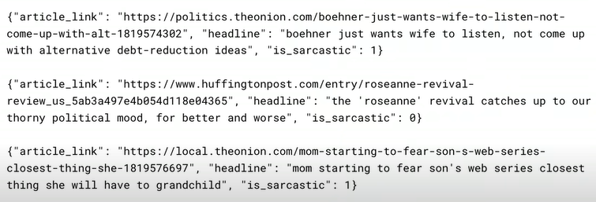

נצטרך להמיר את זה שיהיה בפורמט של פייתון. כדי שבעצם יהיה כולו במערך אחד ארוך . כמו שראינו מקודם בsentences.

בעצם ככה :

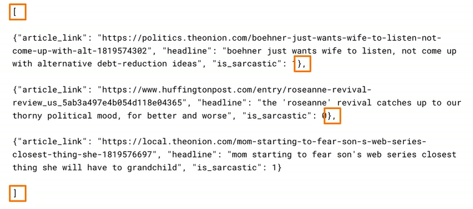

```python
# Run this to ensure TensorFlow 2.x is used
try:
  # %tensorflow_version only exists in Colab.
  %tensorflow_version 2.x
except Exception:
  pass
```

```
Colab only includes TensorFlow 2.x; %tensorflow_version has no effect.
```

```python
import tensorflow as tf
from tensorflow.keras.preprocessing.text import Tokenizer
from tensorflow.keras.preprocessing.sequence import pad_sequences
```

```python
# it was hard to load the data from some reason so i took a little of it by hand...

"""
!wget --no-check-certificate \
    https://storage.googleapis.com/laurencemoroney-blog.appspot.com/sarcasm.json \
    -O /tmp/sarcasm.json

with open("/tmp/sarcasm.json", 'r') as f:
    datastore = json.load(f)

"""

datastore = [
{"article_link": "https://www.huffingtonpost.com/entry/hair-salon-quiet-chair_us_565f0857e4b08e945fed80d2", "headline": "hair salon's 'quiet chair' is a dream for haters of smalltalk", "is_sarcastic": 0},
{"article_link": "https://www.huffingtonpost.com/entry/esports-governing-body-world-esports-association_us_5734fcfbe4b08f96c182b7b0", "headline": "e-sports organizations are going to launch governing body for pro video gaming", "is_sarcastic": 0},
{"article_link": "https://www.theonion.com/philadelphia-museum-of-art-erects-statue-of-overweight-1819592135", "headline": "philadelphia museum of art erects statue of overweight tourist posing next to rocky statue", "is_sarcastic": 1},
{"article_link": "https://www.huffingtonpost.com/entry/holiday-gift-guide-older-people_b_8787888.html", "headline": "9 fabulous gift ideas for older loved ones", "is_sarcastic": 0},
{"article_link": "https://www.theonion.com/bernie-sanders-fills-in-for-factory-worker-unable-to-ta-1819592698", "headline": "bernie sanders fills in for factory worker unable to take time off to vote", "is_sarcastic": 1},
{"article_link": "https://www.huffingtonpost.com/entry/learn-to-fix-the-1-mistak_b_5241320.html", "headline": "learn to fix the no. 1 mistake you are making in yoga practice", "is_sarcastic": 0},
{"article_link": "https://www.huffingtonpost.com/entry/for-the-first-time-chimpa_n_5544061.html", "headline": "for the first time, chimpanzees are making a fashion statement", "is_sarcastic": 0},
{"article_link": "https://www.huffingtonpost.com/entry/michigan-medicaid_us_5af49fa3e4b032b10bf8c60c", "headline": "there's no good excuse for the racist impact of michigan's medicaid proposal", "is_sarcastic": 0},
{"article_link": "https://www.huffingtonpost.com/entry/sasha-malia-obama-lionel-messi-failed-meeting_us_56f448e1e4b014d3fe22a2be", "headline": "sasha and malia obama tried (and failed) to meet soccer superstar in argentina", "is_sarcastic": 0},
{"article_link": "https://www.huffingtonpost.com/entry/lena-headey-cersei-bachelor-insults_us_56a7a563e4b0b87beec60dd0", "headline": "queen cersei reading insults from 'the bachelor' is what tv dreams are made of", "is_sarcastic": 0},
{"article_link": "https://www.theonion.com/fda-approves-new-drug-for-treating-pill-deficiencies-1819577350", "headline": "fda approves new drug for treating pill deficiencies", "is_sarcastic": 1},
{"article_link": "https://local.theonion.com/museum-staff-braces-for-large-group-wearing-same-t-shir-1819570797", "headline": "museum staff braces for large group wearing same t-shirt", "is_sarcastic": 1},
{"article_link": "https://politics.theonion.com/relieved-scott-walker-narrowly-avoids-acknowledging-imm-1819578129", "headline": "relieved scott walker narrowly avoids acknowledging immigrants' humanity during campaign speech", "is_sarcastic": 1},
{"article_link": "https://www.huffingtonpost.com/entry/beyond-the-classroom-expe_b_6920532.html", "headline": "beyond the classroom: experiencing technology innovation up-close-and-personal at sxsw", "is_sarcastic": 0},
{"article_link": "https://www.theonion.com/north-carolina-elects-someone-to-run-out-for-cigarettes-1819565285", "headline": "north carolina elects someone to run out for cigarettes", "is_sarcastic": 1},
{"article_link": "https://www.huffingtonpost.com/entry/volkswagen-executives-prosecution_us_55fd9749e4b00310edf74f5d", "headline": "the justice department pledge to prosecute white-collar criminals is about to face a major test", "is_sarcastic": 0},
{"article_link": "https://www.huffingtonpost.com/entry/death-penalty-redemption-thoughts-on-tsarnaev-and-american-christianity_b_7297998.html", "headline": "death penalty and redemption: thoughts on tsarnaev and american christianity", "is_sarcastic": 0},
{"article_link": "https://local.theonion.com/secret-santa-seems-to-think-you-a-big-laverne-shirley-1821432999", "headline": "secret santa seems to think you a big 'laverne & shirley' fan", "is_sarcastic": 1},
{"article_link": "https://www.theonion.com/magical-gallery-transforms-dull-objects-into-art-1819566921", "headline": "magical gallery transforms dull objects into art", "is_sarcastic": 1},
{"article_link": "https://entertainment.theonion.com/actress-leaves-porn-past-behind-with-new-cinemax-erotic-1819586483", "headline": "actress leaves porn past behind with new cinemax erotic thriller", "is_sarcastic": 1}
]

sentences = [] # headlines
labels = []
urls = []

for item in datastore: # load the require data to each list
    sentences.append(item['headline'])
    labels.append(item['is_sarcastic'])
    urls.append(item['article_link'])
```

```python
from tensorflow.keras.preprocessing.text import Tokenizer
from tensorflow.keras.preprocessing.sequence import pad_sequences
tokenizer = Tokenizer(oov_token = "<OOV>")
tokenizer.fit_on_texts(sentences) # creating token for each word in the test
word_index = tokenizer.word_index # put for them an index

# here we are making our sentences into sequences of tokens , and pad them to the same length with this code.
sequences = tokenizer.texts_to_sequences(sentences)
padded = pad_sequences(sequences,padding='post')
# print(f'{sequences3}\n')
# print(f'{padded3}\n\n')

print(f'{padded[0]}\n')
print(f'{padded.shape}\n')
print("its 26709 sequences, each with 40 tokens.")
```

[output not shown]

in json data , for example . we have from the code :

tokenizer.fit .. and word-index3 .. this output

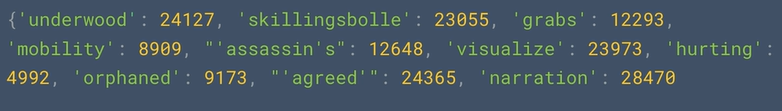

now we have a problem . we dont want a split in the data for training and testing.

we only have a list of 26709 sequences . with python .. its easy in the next code :

we have bunch of sentences in a list and a labels.

to slice them into training and test sets. we gonna do that .

```python
# some value of size..
training_size = 10
training_sentences = sentences[0:training_size]
testing_sentences = sentences[training_size:]
training_labels = labels[0:training_size]
testing_labels = labels[training_size:]
```

but there is a problem ! remember earlier we used the tokenizer to create a word index ? of every word in the set ? that was all very good , but if we really want to test its effectiveness, we have to ensure that the neuralnet only sees the training data , and that it never sees the test data.

so ! we have to rewrite our code to ensure that the tokenizer is just fit to the training data.

here is the new code :

```python
vocab_size = 10
oov_tok = "<OOV>"
max_length = 10
trunc_type='post'
padding_type='post'

"""
like before : 5 steps.
tokenizer = Tokenizer(oov_token = "<OOV>")
tokenizer.fit_on_texts(sentences)
word_index = tokenizer.word_index
sequences = tokenizer.texts_to_sequences(sentences)
padded = pad_sequences(sequences,padding='post')

"""


# instantiate a tokenizer like before.
tokenizer = Tokenizer(num_words = vocab_size,oov_token = oov_tok) # 1
# now we gonna fit the token only on the training sentences
tokenizer.fit_on_texts(training_sentences)# 2

word_index = tokenizer.word_index # 3

training_sequences = tokenizer.texts_to_sequences(training_sentences) # 4
training_padded = pad_sequences(training_sequences,maxlen=max_length,padding=padding_type,truncating = trunc_type) # 5


testing_sequences = tokenizer.texts_to_sequences(testing_sentences) # 4
testing_padded = pad_sequences(testing_sequences,maxlen=max_length,padding=padding_type,truncating = trunc_type)# 5
```

we turned our sentences into numbers with the numbers being tokens representing words.

but how we get meaning from that ?!

and here the part of embendding comes in.

נגיד ויש ראדר על ציר איקס

בצד ימין שלוו זה מעיד על משהו טוב ושמאל משהו רע , כמו בתמונה הבאה נגיד רק שה"וקטור" האמצעי מראה על הקרבה לצד כל שהוא כשיש קלט של מילה מסויימת שרואים אותה בקצה של הוקטור הזה שזז כמו מחוגה :

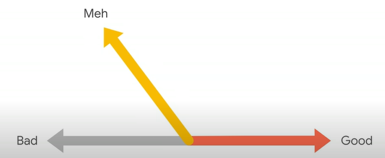

אם נוסיף עוד מילה היא תראה גם מיקום משלה . אם נציב את זה על מערכת צירים באמת נוכל לראות את זה כך :

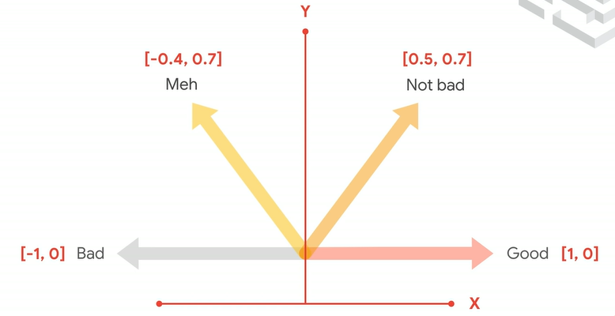

בעזרת הסתכלות על הוקטור נוכל להחליט מה משמעות המילה ואם היא טובה או לא .

עכשיו .. מה יקרה אם יהיה לנו מלא מימדים של זה ?

כמובן שלא נוכל לראות את זה..

מה אם מילים ותוויות עם משמעות כמו סרקסטי ולא סרקסטי יכלו להופיע במערכת צירים רב מימדית שכזו ?

אז בעזרת מה שלמדנו , אנחנו ננסה ללמוד מה הכיוון שבמערכת צירים הרבת מימדים הזאת אמורה להראות.

מילים שהם סרקסטים אמורים להיות קרוב לוקטור הרע ו הלא סרקסטי לכיוון הטוב כמובן.

ככל שנטען יותר ויותר מילים ומשפטים לנתונים שלנו עבור אימון אז ככה הכיוון של הוקטורים ישתנה

וכשיש לנו רשת נוירונים מלאה , וניתן לה סט מילים , זה יכול לחפש את הוקטורים עברו כל מילה , לסכום אותם ואז להביא לנו מספר שיביע אם המשפט הוא סקרסטי או לא . הסכימה בעצם יצרה לנו וקטור אחד ! שמכוון על מיקום כל שהוא במערכת צירים שלנו.

בדיוק מה שאמרתי עד כה . הרעיון הזה הוא בעצם נקרא embedding.

נ.ב במטלה שלנו זה אחרת . כי פה אין משמעות לסדר של המילים , זה רק להמחשבה ראשונית כללית הדוגמא הזאת בקלספיקציה.

```python
#vocab_size = 10000   only a reminder for the value of params.
#max_length = 100
embedding_dim = 16
from tensorflow.keras.layers import Embedding, Dense
model = tf.keras.Sequential([
    # the embedding . where the direction of each word will be learned epoch by epoch.
    tf.keras.layers.Embedding(vocab_size, embedding_dim, input_length=max_length),
    # adding up the vectors like i told you before. but also do an avrage
    tf.keras.layers.GlobalAveragePooling1D(),
    tf.keras.layers.Dense(24, activation='relu'),
    tf.keras.layers.Dense(1, activation='sigmoid')
])
model.compile(loss='binary_crossentropy',optimizer='adam',metrics=['accuracy'])
```

about **"Dense" layer**.

chatGPT say :

The Dense layer in this code is a fully-connected layer. It takes in an input tensor and applies a linear transformation to it, followed by an activation function. The Dense layer in this code has 24 units and the activation function used is the relu (Rectified Linear Activation). This means that the output of each unit in the Dense layer will be the input value if it is positive, and 0 if it is negative. The Dense layer with 1 unit and the sigmoid activation function at the end is used for binary classification. The output of this layer will be a probability value between 0 and 1, indicating the probability that the input data belongs to the positive class.

and about **model.compile()**:

model.compile() is used to configure the learning process of the model. It takes three important arguments:

1. loss: It specifies the loss function that should be used to calculate the error between the predicted output and the true output. In this case, the binary_crossentropy loss is used for binary classification.
2. optimizer: It specifies the optimizer that should be used to minimize the loss. In this case, the adam optimizer is used. It is a gradient-based optimization algorithm that is generally used in deep learning models.
3. metrics: It specifies the metrics that should be used to evaluate the model. In this case, the accuracy metric is used to calculate the accuracy of the model on the training and validation sets.

Together, these three arguments define the learning process of the model. The model will use the specified loss function and optimizer to learn the weights and biases of the model, and the specified metrics will be used to evaluate the model's performance on the training and validation sets.

עכשיו לאימון .

for :

"history = model.fit(training_padded,training_labels,epochs= num_epoches,validation_data = (testing_padded,testing_labels),verbose =2)"

this happen :

" ValueError: Failed to find data adapter that can handle input: <class 'numpy.ndarray'>, (<class 'list'> containing values of types {"<class 'int'>"})"

It looks like the input data passed to model.fit() is in the wrong format. The training_padded and testing_padded variables should be numpy arrays or tensors, but it seems that they are lists of integers.

```python
# Need this block to get it to work with TensorFlow 2.x
import numpy as np
training_padded = np.array(training_padded)
training_labels = np.array(training_labels)
testing_padded = np.array(testing_padded)
testing_labels = np.array(testing_labels)
```

training is now as simple as model.fit using the training data and lables and specifying the testing padded and lables for the validation data

```python
num_epoches = 3

history = model.fit(training_padded,training_labels,epochs= num_epoches,validation_data = (testing_padded,testing_labels),verbose =2)
```

```
1/1 - 4s - loss: 0.6905 - accuracy: 0.8000 - val_loss: 0.6961 - val_accuracy: 0.3000 - 4s/epoch - 4s/step
1/1 - 0s - loss: 0.6886 - accuracy: 0.8000 - val_loss: 0.6974 - val_accuracy: 0.3000 - 42ms/epoch - 42ms/step
1/1 - 0s - loss: 0.6869 - accuracy: 0.8000 - val_loss: 0.6987 - val_accuracy: 0.3000 - 39ms/epoch - 39ms/step
```

(when i had the full data)

so how do we use this to establish sentiment for new sentences ?

```python
# the first one is very sarcastic , and the other one is quite plain and boring.
sentence = ["granny starting to fear spiders in the garden might be real",
            "the weather today is bright and sunny"]
# we will take the tokenizer that we created earlier to convert them to sequences.
#this way the words will have the same tokens as the training set.
sequences = tokenizer.texts_to_sequences(sentence)
# padding them to be in the same dimensions as those in the training set and use the same padding type.
padded = pad_sequences(sequences,maxlen=max_length,padding=padding_type,truncating=trunc_type)
# and now we can predict on the the padded set.
print(model.predict(padded))
```

```
[[0.4937721]
 [0.4940328]]
```

```python
model.summary()
```

```
Model: "sequential"
_________________________________________________________________
 Layer (type)                Output Shape              Param #
=================================================================
 embedding (Embedding)       (None, 10, 16)            160

 global_average_pooling1d (G  (None, 16)               0
 lobalAveragePooling1D)

 dense (Dense)               (None, 24)                408

 dense_1 (Dense)             (None, 1)                 25

=================================================================
Total params: 593
Trainable params: 593
Non-trainable params: 0
_________________________________________________________________
```

until now .. what we have seen?

we saw how to tokenize text and how to use sequences of tokens, to train a neural network. in particular we saw how to classifed text by sentiments.

now we gonna talk about genetating test . this part including RNN.

until now the order of the words didnt matter. what determind the sentiment was the vector that resulted in adding up all of the individual vectors for the endividual words.

the direction of that vector roughly gave us the sentiments.

but it we're going to generate text , **the order does matter !**

for an example.. "today the weather is gorgeous and i see a beatiful blue .." if we want to predict the next word , and the concept of creating text really boils down to predicting the next word , you are probably say, "sky" becuse that comes after "beatiful" and "blue" and the context is the "weather"

Because of using RNN

Think for a moment. Fibonacci series. remember that ? It creates a sequence based on the first numbers. For example: 1,2,3,5,8,13.. If we look at the first number.. It is as if it is contained in numbers that have been calculated ahead.

Actually... the number 5 for example is calculated by the 2 preceding it, 2+3.

But 3 is calculated from 1+2

So actually you can imagine that 1,2 are words! that in fact their content .. thinks further in the chain and actually considered his existence. that 1 still continues to exist throughout the series.

so how we gonna do that ?

LSTM.

from now on there is a few models that can train the model .

in task 4 i will show how it is done .

```python
"""
before:
model = tf.keras.Sequential([
    # the embedding . where the direction of each word will be learned epoch by epoch.
    tf.keras.layers.Embedding(vocab_size, embedding_dim, input_length=max_length),
    # adding up the vectors like i told you before. but also do an avrage
    tf.keras.layers.GlobalAveragePooling1D(),
    tf.keras.layers.Dense(24, activation='relu'),
    tf.keras.layers.Dense(1, activation='sigmoid')
])
now:

#vocab_size = 10000   only a reminder for the value of params.
#max_length = 100
# embedding_dim = 16
from tensorflow.keras.layers import Embedding, LSTM, Dense, Bidirectional

model = tf.keras.Sequential([
    #
    tf.keras.layers.Embedding(tokenizer.vocab_size,64),
    # "tf.keras.layers.LSTM(64)" takes a numeric parameter for the number of hidden nodes within it.
    #and this is also the dimensionality of the output space from this layer.
    # Bidirectional : if you want to be bi-directional , we can wrap this layer in a bi-directional like this,and you are good to go.
    # remember that this will look at your sentence forward and backward !
    #learn the best for each params for each and then merge them.
    tf.keras.layers.Bidirectional(tf.keras.layers.LSTM(64)),
    tf.keras.layers.Dense(64, activation='relu'),
    tf.keras.layers.Dense(1, activation='sigmoid')
])

model = tf.keras.Sequential([
    #
    tf.keras.layers.Embedding(tokenizer.vocab_size,64),
    # we can also stack LSTM layers so that the output of one layer get fed into the next layer.
    #note: we gonna need to write "return_sequences" for each layer we want to move the output for another layer.
    tf.keras.layers.Bidirectional(tf.keras.layers.LSTM(64,return_sequences=True)),
    tf.keras.layers.Bidirectional(tf.keras.layers.LSTM(32)),
    tf.keras.layers.Dense(64, activation='relu'),
    tf.keras.layers.Dense(1, activation='sigmoid')
])
"""
```

```python
n = adsa()
```

[output not shown]

```python
%tensorflow_version 2.x
import tensorflow as tf
!pip install tensorboardX
!pip install language_models
device_name = tf.test.gpu_device_name()
if device_name != '/device:GPU:0':
  raise SystemError('GPU device not found')
print('Found GPU at: {}'.format(device_name))

# !git clone https://github.com/pbloem/language-models.git
!git clone https://github.com/GuyKabiri/language_models
```

[output not shown]

add from keras.utils import pad_sequences to utils, remove sequence from line 169

in utils.py - not needed change from scipy.misc import logsumexp in line 11 to "from scipy.special import logsumexp"

```python
import keras

import keras.backend as K
from keras.datasets import imdb
from keras.layers import  LSTM, Embedding, TimeDistributed, Input, Dense,Bidirectional
from keras.models import Model
from tensorflow.python.client import device_lib

from tqdm import tqdm
import os, random

from argparse import ArgumentParser

import numpy as np

from language_models import util

CHECK = 5
```

### Code for learning and understanding the functions allready inside the task start

```python
from keras.preprocessing.text import text_to_word_sequence
from nltk import FreqDist
MY_EXTRA_SYMBOLS = util.EXTRA_SYMBOLS
"""
load_words function in util :

Reading text until some limit we choose.
x:
split lines until "\n"
its gonna be our x

i2w:
finding the max len of x (make sure the line is not up then what we passed into the function to be, maybe some one want our sequences to be short)
now tokenizer them.
Creating the vocabulary set of tokens with the most common words (saving place for EXTRA_SYMBOLS)
Creating an array of words from the vocabulary set and adding the EXTRA_SYMBOLS to the start.
it contains array as index-to-word dictionary and its value is i2w

w2i:
now we make an array of words from the indexs of the words.. like the "word_index = tokenizer.word_index"
that tokened and indexed will be in value w2i , but only the words in the order of the indexs.

what we got  ?
x - was : our sequences per line
x - now : our index per each word at each line ,like a transalte
i2w - array as index-to-word dictionary
w2i - an ordered array with the words for each index in our history of words collected.

The "source" parameter is a string that represents the file path to the text file that the function reads from.

The "vocab_size" parameter controls the maximum number of !! unique !! words that the function retains from the text file.
If there are more unique words than this, the function only keeps the "vocab_size" most frequent words and replaces the rest with the special token "<UNK>".

The "limit" parameter is an optional parameter that allows you to limit the number of characters read from the text file.
 This is useful when you are working with large corpora and want to limit the amount of data loaded for testing or debugging purposes.

The "max_length" parameter is an optional parameter that allows you to limit the maximum number of words in each sentence.
If the sentence has more words than the max_length, this sentence is removed..
"""

def load_wordsPractice(source, vocab_size=10000, limit=None, max_length=None):
    x_data = source
    print('raw data read')

    if limit is not None:
        x_data = x_data[:limit]
                                          # x_data.lower().split to change !
    x = [text_to_word_sequence(x) for x in x_data.lower().split('\n') if len(x) > 0]

    if max_length is not None:
        x = [s for s in x if len(s) <= max_length]

    dist = FreqDist(np.hstack(x))
    x_vocab = dist.most_common(vocab_size - len(MY_EXTRA_SYMBOLS))
    i2w = [word[0] for word in x_vocab]
    i2w = MY_EXTRA_SYMBOLS + i2w
    w2i = {word:ix for ix, word in enumerate(i2w)}
    for i, sentence in enumerate(x):
        for j, word in enumerate(sentence):
            if word in w2i:
                x[i][j] = w2i[word]
            else:
                x[i][j] = w2i['<UNK>']

    return x, w2i, i2w

x_data = "i love my dog,my dog have a name,my name is dori,dori are a man,dori is not a dog"

x, w2i, i2w = load_wordsPractice(x_data,vocab_size = 20)
"""
Remember!

In class we talked about how to translate from one language to another.
This is done using encoder, decoder.
The logic that works behind this is that every word that exists in the world has an index in the general dictionary.

In any language we can turn the words into tokens (basically separate all the words and define each word on its own.)

Then if we want to translate, we will do a translation for the index in her international dictionary!

And actually when translated into the other language..

Even there the same word is according to the same international index!

And from that we can translate.
Because actually in the international dictionary every possible word has the same numerical representation.

for example :
דורי : 1 , אוכל : 2 , פסטה : 3
dori : 1 , eat : 2 , pasta : 3

"""
print(f'x:\n{x}\nw2i:\n{w2i}\ni2w:\n{i2w}')
# what we got  ?
# x - was : our sequences per line
# x - now : our index per each word at each line that represent the word
# i2w - array as index-to-word dictionary like word_index dict in tokenizer.
# w2i - an ordered array with the words for each index in our history of words collected.
#for a reminder:
# x_data = "i love my dog,
#           my dog have a name,
#           my name is dori,
#           dori are a man,
#           dori is not a dog"
```

```
raw data read
x:
[[10, 11, 4, 5, 4, 5, 12, 6, 8, 4, 8, 9, 7, 7, 13, 6, 14, 7, 9, 15, 6, 5]]
w2i:
{'<PAD>': 0, '<START>': 1, '<UNK>': 2, '<EOS>': 3, 'my': 4, 'dog': 5, 'a': 6, 'dori': 7, 'name': 8, 'is': 9, 'i': 10, 'love': 11, 'have': 12, 'are': 13, 'man': 14, 'not': 15}
i2w:
['<PAD>', '<START>', '<UNK>', '<EOS>', 'my', 'dog', 'a', 'dori', 'name', 'is', 'i', 'love', 'have', 'are', 'man', 'not']
```

```python
# no use in this task .. we have sparse_categorical_crossentropy that using that kind of thing inside it.
def to_categoricalPractice(batch, num_classes):
    """
"num_classes" refer to the total number of unique words in the vocabulary
for each sequences that represent in a list.
the easy way to say it .. it the num of column / len of the list
or how much i want it to be ! maybe i want any list to have extra 1 place to be zero also..
"""
    b, l = batch.shape
    out = np.zeros((b, l, num_classes))
    for i in range(b):
        seq = batch[0, :]
        out[i, :, :] = keras.utils.to_categorical(seq, num_classes=num_classes)

    return out

batch = np.array([[1, 2, 3, 0], [4, 5, 2, 0], [3, 4, 5, 0]])
num_classes = 4
one_hot_batch = to_categoricalPractice(batch, num_classes)
print(one_hot_batch)
```

```
[[[0. 1. 0. 0.]
  [0. 0. 1. 0.]
  [0. 0. 0. 1.]
  [1. 0. 0. 0.]]

 [[0. 1. 0. 0.]
  [0. 0. 1. 0.]
  [0. 0. 0. 1.]
  [1. 0. 0. 0.]]

 [[0. 1. 0. 0.]
  [0. 0. 1. 0.]
  [0. 0. 0. 1.]
  [1. 0. 0. 0.]]]
```

```python
# no use in our task
def interpolate(start, end, steps):
#This is a common interpolation technique and is useful in many machine learning, computer vision,
#and other data science applications. The most common use case of this function is using it to generate data,
#where the start and end could be real data points and the steps are the number of data points you want to generate between the start and end
    result = np.zeros((steps+2, start.shape[0]))
    for i, d in enumerate(np.linspace(0,1, steps+2)):
        result[i, :] = start * (1-d) + end * d

    return result
from scipy.special import logsumexp

from collections import defaultdict, Counter, OrderedDict

def sample_logitsPractice(preds, temperature=1.0):
    """
    Sample an index from a logit vector.

    :param preds:
    :param temperature:
    :return:
    """
    preds = np.asarray(preds).astype('float64')

    if temperature == 0.0:
        return np.argmax(preds)
# the divied is done to ensure that the resulting array of probabilities sum to 1 (This is called the softmax operation).
    preds = preds / temperature
    preds = preds - logsumexp(preds)
#randomly choose an index from the preds array, with the probabilities of each index
# its happing becuse if we just take each time the highest value .. we can get the same asnwer again and again !
# like we talked in class. the word "and" is very very common.
#and becuse of that we dont want the word to be always the currect choice !


    #param 1 :from which to choose an item,
    #param 2 :the number of items to choose
    #param 3:list of float probabilities which define the likelihood of each item being chosen.

    choice = np.random.choice(len(preds), 1, p=np.exp(preds))

    return choice

# This function is used to convert a list of sentence represented by a list of indexes to a list of sentences represented by a list of words.
class OrderedCounter(Counter, OrderedDict):
    'Counter that remembers the order elements are first encountered'

    def __repr__(self):
        return '%s(%r)' % (self.__class__.__name__, OrderedDict(self))

    def __reduce__(self):
        return self.__class__, (OrderedDict(self),)

def idx2word(idx, i2w, pad_idx):

    sent_str = [str()]*len(idx)

    for i, sent in enumerate(idx):

        for word_id in sent:

            if word_id == pad_idx:
                break
            sent_str[i] += i2w[str(word_id.item())] + " "

        sent_str[i] = sent_str[i].strip()


    return sent_str
```

# Task 4 NN Starting Here !

# Global defines

```python
class Args:
  epochs = 20 # Number of epochs
  embedding_size = 300 # Size of the word embeddings on the input layer.
  out_every = 1 # Output every n epochs.
  lr = 0.001 # Learning rate
  batch = 128 # Batch size
  task = 'wikisimple'
  data = './data' # Data file. Should contain one sentence per line.
  lstm_capacity = 256
  max_length = None # Sentence max length.
  top_words = 10000 # Word list size.
  limit = None # Character cap for the corpus - not relevant in our exercise.
  tb_dir = './runs/words' # Tensorboard directory
  seed = -1 # RNG seed. Negative for random (seed is printed for reproducability).
  extra = None # Number of extra LSTM layers.
  # trainingSize = 0.8
  # validationSize = 0.1
  # testSize = 0.1
options = Args()
```

# loading and prepering the data

```python
#seed : word to start with

if options.seed < 0:
    seed = random.randint(0, 1000000)
    print('random seed: ', seed)
    np.random.seed(seed)
else:
    np.random.seed(options.seed)

if options.task == 'wikisimple':
                                                     # reads data from ,maximum number of unique word , limit the number of characters read from the text file.
    x, w2i, i2w = util.load_words(util.DIR + '/datasets/wikisimple.txt', vocab_size=options.top_words, limit=options.limit)
    # what we got  ?
    # x - was : our sequences per line
    # x - now : our list of indexs per each word at each line ,like a transalte
    # i2w - array as index-to-word dictionary like word_index dict in tokenizer.
    # w2i - an ordered dict with the words for each index in our history of words collected.
    # Finding the length of the longest sequence
    x_max_len = max([len(sentence) for sentence in x])

    numwords = len(i2w)
    print('max sequence length ', x_max_len)
    print(numwords, 'distinct words')
  # until now we did like my previous research:
  # split lines until "\n"
  # tokenizer them.
  # Creating the vocabulary set of tokens
  # word_index them

  # now we gonna need to padd them , becuse there are not at the same size of matrix .we gonna need to add zeros.
  # so here.. we gonna "update" x will padding in the function batch_pad.
    x = util.batch_pad(x, options.batch, add_eos=True)
    print('Finished data loading. ', sum([b.shape[0] for b in x]), ' sentences loaded')
    print(f'num of batches is : {len(x)}\n')
    print(f'num of sequences in x[0:](each one) : {len(x[0])}\n')
    print("there is a few word indexs from w2i dict with the most frequently")
    for i,(key, value) in enumerate(w2i.items()):
      if i >10:
        break
      print(f'{key} : {value}')
    print(f'len(x[0][0]) : {len(x[0][0])}\n')
    print(f'len(x[0][1]) : {len(x[0][1])}\n')
    print(f'len(x[2][0]) : {len(x[2][0])}\n')
    print(f'len(x[2][1]) : {len(x[2][1])}\n')

    # for i in range(len(x[0][0])):
    #   print({x[0][0][i]})
else:
    raise Exception('Task {} not recognized.'.format(options.task))
```

```
random seed:  636517
raw data read
max sequence length  132
10000 distinct words
max length per batch:  [15, 15, 16, 16, 16, 16, 17, 17, 17, 17, 17, 17, 17, 17, 17, 18, 18, 18, 18, 18, 18, 18, 18, 18, 18, 18, 18, 18, 19, 19, 19, 19, 19, 19, 19, 19, 19, 19, 19, 19, 19, 19, 19, 19, 19, 20, 20, 20, 20, 20, 20, 20, 20, 20, 20, 20, 20, 20, 20, 20, 20, 20, 21, 21, 21, 21, 21, 21, 21, …
Finished data loading.  29741  sentences loaded
num of batches is : 233

num of sequences in x[0:](each one) : 128

there is a few word indexs from w2i dict with the most frequently
<PAD> : 0
<START> : 1
<UNK> : 2
<EOS> : 3
the : 4
of : 5
and : 6
in : 7
a : 8
to : 9
is : 10
len(x[0][0]) : 15

len(x[0][1]) : 15

len(x[2][0]) : 16

len(x[2][1]) : 16
```

```python
def parsing_loss(y_true, y_pred):
    return K.sparse_categorical_crossentropy(y_true, y_pred, from_logits=True)
```

K coming from -> import keras.backend as K inside util pack

Instead of one-hot encoded labels, sparse categorical crossentropy allows you to use integer encoded labels.

from_logits = the function applies a softmax activation function on y_pred to produce probability values before calculating the loss

y_true should be (batch_size(number of samples in your batch), 1)

its like "tf.keras.utils.to_categorical(labels,num_classes=total_words)"

its should look like that i think :

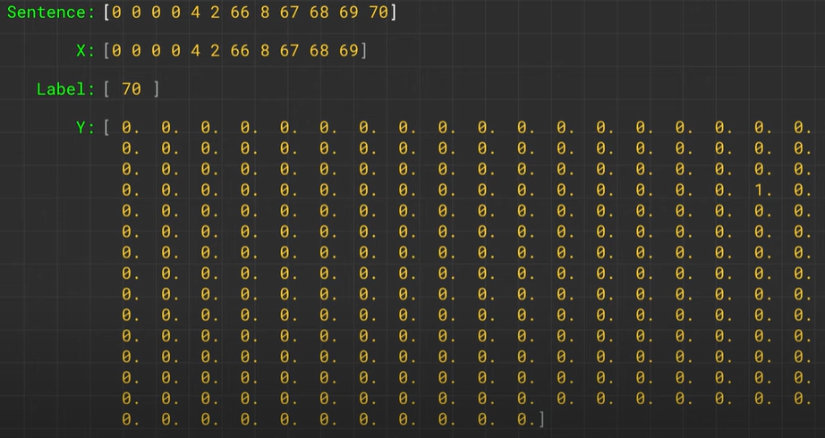

# Required functions

**section 1**

```python
from sklearn.model_selection import train_test_split
def splitData(text_data):
  train_data, test_data = train_test_split(text_data, test_size=0.2,shuffle=True, random_state=42)
  val_data, test_data = train_test_split(test_data ,test_size=0.5,shuffle=True, random_state=42)
  return train_data , val_data,test_data

train_text, valid_text, test_text = splitData(x)

lens = {'train_text': len(train_text), 'valid_text': len(valid_text), 'test_text': len(test_text)}
for key, value in lens.items():
    print(f'{key} len - {value}')
```

```
train_text len - 186
valid_text len - 23
test_text len - 24
```

the best language model and is one that best predicts an unseen test set . perplexity:

note: one of intrinsic evaluation is perplexity

- that is the probability of the test set , normalized by the number of words.
- at any point in a sentence is on average how many things could occur next
- gives the highest P(sentence))

minimizing perplexity is the same as maximizing probability

# Required functions

**section 2**

```python
def perplexity(y_true, y_pred):
    loss = parsing_loss(y_true, y_pred)
    perplexity = K.exp(loss)
    return perplexity
```

# Required functions

**section 3 + 4 [Models]**

I looked on the Internet for ways to teach the model in the opposite way also as requested in the assignment, and I found 2 ways to do it.

- bidirectional
- go_backwards parameter

In general, bidirectional layers are more powerful than reversing the input sequence with the go_backwards parameter. Because bidirectional layers process the input sequence in two different directions and combine the information from both, they can capture more meaningful patterns in the data and provide more accurate predictions.

by the way , i saw the import for : tf.keras.Model and i found this:

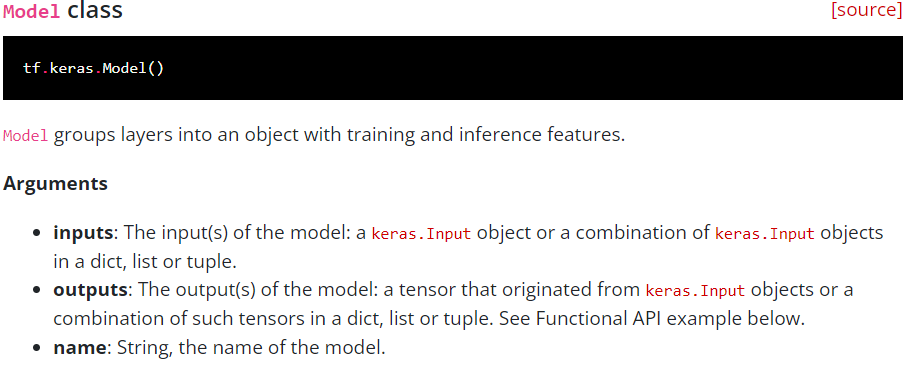

with out giving the name , the Model will call it by the order of models i created.

```python
def My_Sequential(How_To_Name_It,doBackwards=False,doBidirectional=False):
  if((doBackwards == True) and (doBidirectional == True)):
    print("we want only 1 choise of back learner")
    return
  input = Input(shape=(None, ))
  embedding = Embedding(numwords, options.embedding_size, input_length=None)
  embedded = embedding(input)

  if(doBidirectional == True):
    decoder_lstm = Bidirectional(LSTM(options.lstm_capacity, return_sequences=True))
    h = decoder_lstm(embedded)
    if options.extra is not None:
      for _ in range(options.extra):
        h = Bidirectional(LSTM(options.lstm_capacity, return_sequences=True))(h)
  else:
    decoder_lstm = LSTM(options.lstm_capacity, return_sequences=True, go_backwards=doBackwards)
    h = decoder_lstm(embedded)
    if options.extra is not None:
      for _ in range(options.extra):
        h = LSTM(options.lstm_capacity, return_sequences=True,go_backwards=doBackwards)(h)
  fromhidden = Dense(numwords, activation='linear')
  out = TimeDistributed(fromhidden)(h)
  #tf.keras.Model
  model = Model(input, out,name = How_To_Name_It)
  opt = tf.keras.optimizers.Adam(lr=options.lr)
  lss = parsing_loss
  model.compile(opt, lss,metrics = [perplexity])
  model.summary()
  return model



def train_some_text_OR_evaluate(model, text_set, to_evaluate=False):
    if to_evaluate:
        for batch in tqdm(text_set):
            n, l = batch.shape
            batch_shifted = np.concatenate([np.ones((n, 1)), batch], axis=1) # prepend start symbol
            batch_out = np.concatenate([batch, np.zeros((n, 1))], axis=1)    # append pad symbol
            results = model.test_on_batch(batch_shifted, batch_out[:, :, None], return_dict=True)
            #return_dict = True : This parameter is a boolean value that controls whether the return value should be a dict containing the metric results.
        return results
    else:
        for epoch in range(options.epochs):
            for batch in tqdm(text_set):
                n, l = batch.shape
                batch_shifted = np.concatenate([np.ones((n, 1)), batch], axis=1)  # prepend start symbol
                batch_out = np.concatenate([batch, np.zeros((n, 1))], axis=1)     # append pad symbol
                model.train_on_batch(batch_shifted, batch_out[:, :, None])

model_num = 1
models = dict()
for extra in [0, 1]:
  options.extra = extra
  for go_backwards in [True, False]:
    #options.extra = extra
    This_name = f'Model_num{model_num}_with_{extra}_Extras_using_backwards_{go_backwards}'
    model_num += 1
    model = My_Sequential(How_To_Name_It=This_name, doBackwards=go_backwards)
    models[This_name] = model
    train_some_text_OR_evaluate(model,train_text)

for extra in [0, 1]:
  options.extra = extra
  This_name = f'Model_num{model_num}_with_{extra}_Extras_using_Bidirectional_True'
  model_num += 1
  model = My_Sequential(How_To_Name_It=This_name, doBidirectional=True)
  models[This_name] = model
  train_some_text_OR_evaluate(model,train_text)

print(f'\n\nTotal of {model_num - 1} models created .\n\n')
# models = dict()
# options.extra = 0
# This_name = f'Model_{0}_Extra_using_Bidirectional_True'
# model = My_Sequential(How_To_Name_It=This_name, doBidirectional=True)
# models[This_name] = model
# train_some_text_OR_evaluate(model,train_text)
# model.summary()
```

```
Model: "Model_num1_with_0_Extras_using_backwards_True"
_________________________________________________________________
 Layer (type)                Output Shape              Param #
=================================================================
 input_1 (InputLayer)        [(None, None)]            0

 embedding_1 (Embedding)     (None, None, 300)         3000000

 lstm (LSTM)                 (None, None, 256)         570368

 time_distributed (TimeDistr  (None, None, 10000)      2570000
 ibuted)

=================================================================
Total params: 6,140,368
Trainable params: 6,140,368
Non-trainable params: 0
_________________________________________________________________
```

```
Model: "Model_num2_with_0_Extras_using_backwards_False"
_________________________________________________________________
 Layer (type)                Output Shape              Param #
=================================================================
 input_2 (InputLayer)        [(None, None)]            0

 embedding_2 (Embedding)     (None, None, 300)         3000000

 lstm_1 (LSTM)               (None, None, 256)         570368

 time_distributed_1 (TimeDis  (None, None, 10000)      2570000
 tributed)

=================================================================
Total params: 6,140,368
Trainable params: 6,140,368
Non-trainable params: 0
_________________________________________________________________
```

```
Model: "Model_num3_with_1_Extras_using_backwards_True"
_________________________________________________________________
 Layer (type)                Output Shape              Param #
=================================================================
 input_3 (InputLayer)        [(None, None)]            0

 embedding_3 (Embedding)     (None, None, 300)         3000000

 lstm_2 (LSTM)               (None, None, 256)         570368

 lstm_3 (LSTM)               (None, None, 256)         525312

 time_distributed_2 (TimeDis  (None, None, 10000)      2570000
 tributed)

=================================================================
Total params: 6,665,680
Trainable params: 6,665,680
Non-trainable params: 0
_________________________________________________________________
```

```
Model: "Model_num4_with_1_Extras_using_backwards_False"
_________________________________________________________________
 Layer (type)                Output Shape              Param #
=================================================================
 input_4 (InputLayer)        [(None, None)]            0

 embedding_4 (Embedding)     (None, None, 300)         3000000

 lstm_4 (LSTM)               (None, None, 256)         570368

 lstm_5 (LSTM)               (None, None, 256)         525312

 time_distributed_3 (TimeDis  (None, None, 10000)      2570000
 tributed)

=================================================================
Total params: 6,665,680
Trainable params: 6,665,680
Non-trainable params: 0
_________________________________________________________________
```

```
Model: "Model_num5_with_0_Extras_using_Bidirectional_True"
_________________________________________________________________
 Layer (type)                Output Shape              Param #
=================================================================
 input_5 (InputLayer)        [(None, None)]            0

 embedding_5 (Embedding)     (None, None, 300)         3000000

 bidirectional (Bidirectiona  (None, None, 512)        1140736
 l)

 time_distributed_4 (TimeDis  (None, None, 10000)      5130000
 tributed)

=================================================================
Total params: 9,270,736
Trainable params: 9,270,736
Non-trainable params: 0
_________________________________________________________________
```

```
Model: "Model_num6_with_1_Extras_using_Bidirectional_True"
_________________________________________________________________
 Layer (type)                Output Shape              Param #
=================================================================
 input_6 (InputLayer)        [(None, None)]            0

 embedding_6 (Embedding)     (None, None, 300)         3000000

 bidirectional_1 (Bidirectio  (None, None, 512)        1140736
 nal)

 bidirectional_2 (Bidirectio  (None, None, 512)        1574912
 nal)

 time_distributed_5 (TimeDis  (None, None, 10000)      5130000
 tributed)

=================================================================
Total params: 10,845,648
Trainable params: 10,845,648
Non-trainable params: 0
_________________________________________________________________
```

```
Total of 6 models created .
```

# Required functions

**section 5 + 6 + 7 + 8 + 9**

seq - משפט מיוצג במספרים

senteces - משפט

The assignment asks to calculate the probability that a sentence will appear.

So basically.. You want me to multiply all the conditional probabilities.

Required functions: Decode -> translate index to word encode -> translate word to index generate_seq - > we have it ! it will give up a random line that start with the seed we give him and and return the seq he found by indexs. but first ! we need to give him a numric param .. becuse he is searching for us the seq.. after that we gonna decode it to sentece again and see what we got. all of that i can do in one function that : 1.encode 2.call the function generate_seq 3.decode and return sentence.

so i will make a function that mul them and thats it .

```python
# takes a list of word indexes and converts them back to the original words using an index-to-word mapping
def decode(seq, _i2w = i2w):
    # seq = np.array(seq)
    return ' '.join([_i2w[idx] if idx < len(_i2w) else '<UNK>' for idx in seq])

# get(word,1) if the word is not there -> get 1 that he is <UNK>(needs to check which index he is)
def encode(sentence, _w2i = w2i):
    words = sentence.split()
    return np.array([_w2i.get(word, 2) for word in words])
```

```python
"""
generate_seq function using the trained model to predict the probability
distribution of the next word in the sequence, given the current sequence,
and samples a new word from this distribution.
"""
# its just give me an indexs of words that start at seed index or a start point i give that .
def generate_seq_with_prob(model : Model, seed, size, temperature=1.0):# Greedy Text generator
    ls = seed.shape[0]
    #This code used the first token of an encoded sentence as a seed,
    #and add zeros to the right side of the seed to form the input to the language model in order to generate the rest of the sentence.
    tokens = np.concatenate([seed, np.zeros(size - ls)])
    prob = 1
    for i in range(ls, size):
        probs = model.predict(tokens[None,:])
        # Extract the i-th probability vector and sample an index from it
        #it uses the util.sample_logits() to sample the next token,
        #while they could also use torch.argmax() to select the token with the highest probability.
        # but not always. becuse we can be stuck with the same word like 'and' over and over so they select randomly between the highest probs..
        next_token = util.sample_logits(probs[0, i-1, :], temperature=temperature)
        prob *= abs(probs[0, i-1, next_token])
        tokens[i] = next_token
    return [int(t) for t in tokens] , prob / options.top_words #A list of integers representing a samples sentence
```

```python
def generate_sen(model, size, start_from='<START>', temperature=1):
  seed = encode(start_from)
  sequence , theProb = generate_seq_with_prob(model, seed=seed,  size=size, temperature=temperature)
  sentence = decode(sequence)
  return sentence , theProb
  # getting the sentnce after transaltion


def print_generated_sentences_with_probability(all_models, start_from='i love', size=7, temperatures=[0.1, 1, 10],s = ' - '):
    input_qu = input(f'For a printing sentences with the built-in values :\n start_from = {start_from}, size = {size}\n press 1\nfor your own params press 2\n')
    if(int(input_qu) == 2):
      start_from , size = enter_which_sentence_you_want_to_check()
    else:
      print(f'\n\nThe defult start_from : {start_from} and size to calculate is: {size}')
      print(f'\nstart calc..\n')
    for k, v in all_models.items():
      print(f'model name: {k}\n')
      for temperature in temperatures:
          sentence , prob = generate_sen(v, size, start_from=start_from, temperature=temperature)
          print(f'temperature={temperature}: {sentence}, probability={prob}')
      print(f'\n\n{s*30}\n\n')


def enter_which_sentence_you_want_to_check():
  input_string = input("Please enter some text to check sentences with it and probabilitys: ")
  input_size = input("Do you want the size to be the same as the number of words you entered or more? (yes/no)")
  if input_size.lower() == 'yes':
    word_list = input_string.split()
    num_words_toCheck = len(word_list)
  else:
    num_words_toCheck = input("Enter the number of words you want to calculate: ")
    word_list = input_string.split()[:int(num_words_toCheck)]
  num_words_in_input = len(word_list)
  print(f'\n\nThe number of words in your input is: {num_words_in_input} and size to calculate is: {num_words_toCheck}')
  print(f'\nstart calc..\n')
  return input_string , num_words_toCheck

def print_perplexity_losses(all_models,s = '-',**data):
  for name, model in all_models.items():
    print(f'\n\t{name}\n')
    results = [train_some_text_OR_evaluate(model, data[dataset], to_evaluate=True) for dataset in ['x_train', 'x_valid', 'x_test']]
    for i, res in enumerate(results):
        print(f"\t\n{['train', 'valid', 'test'][i]}: loss={res['loss']:.5f}, perplexity={res['perplexity']:.5f}")
    print(f'\n{s*40}\n')


def predict_next_word(model, word, temperature=1.0):
    # Encode the input word as a sequence of integers
    input_sequence = encode(word)
    # Pass the input sequence through the model to get the probability distribution of the next word
    probs = model.predict(input_sequence[None, :])
    # Sample the next word from the probability distribution
    next_word_index = util.sample_logits(probs[0, -1, :], temperature=temperature)# [0:i] for all the sentnce after
    # Decode the index of the next word to get the actual word
    next_word = decode(next_word_index) # was in []
    return next_word


def UI(model):
  word = input("enter word")
  predict_next_word(word)
```

# perplexity for each model

```python
data = {'x_train': train_text, 'x_valid': valid_text, 'x_test': test_text}
print_perplexity_losses(models, **data)
```

```
	Model_num1_with_0_Extras_using_backwards_True
```

```
train: loss=4.88460, perplexity=2138.81201

valid: loss=5.60122, perplexity=153044.18750

test: loss=5.90324, perplexity=1631733.12500

----------------------------------------


	Model_num2_with_0_Extras_using_backwards_False
```

```
train: loss=4.18646, perplexity=1660.81738

valid: loss=4.84622, perplexity=331716.81250

test: loss=5.10761, perplexity=4440036.00000

----------------------------------------


	Model_num3_with_1_Extras_using_backwards_True
```

```
train: loss=1.14514, perplexity=80.82359

valid: loss=1.14374, perplexity=177.46681

test: loss=1.22713, perplexity=70397240.00000

----------------------------------------


	Model_num4_with_1_Extras_using_backwards_False
```

```
train: loss=5.08626, perplexity=5267.11279

valid: loss=5.10921, perplexity=12748.68848

test: loss=5.34883, perplexity=104714.74219

----------------------------------------


	Model_num5_with_0_Extras_using_Bidirectional_True
```

```
train: loss=0.03542, perplexity=1.05184

valid: loss=0.49246, perplexity=2189.35645

test: loss=0.57260, perplexity=243579.56250

----------------------------------------


	Model_num6_with_1_Extras_using_Bidirectional_True
```

```
train: loss=0.16073, perplexity=1.51342

valid: loss=0.38146, perplexity=265.49417

test: loss=0.43529, perplexity=13608.25000

----------------------------------------
```

# checking if cupcakes is selected to be in our seed [seed:]

as you will see .. cupcakes is not in our vocab..

So without a choice I will calculate the probability for the replacement for

the sentence 'i love cup cake'

note: i try so many times to get cupcakes in my vocab .. but i didnt got it..

```python
def isWordInOurVocab(word,vocab=i2w,dictionary=w2i):
    print(f'searching for word : {word}\n')
    print(f'The word is {"in" if word in vocab else "NOT in"} our vocab\n')
    word = [key for key in dictionary.keys() if key.startswith(prefix)]
    print(word or f'{prefix} prefix not found\n')
    print('-'*30)

prefixs = ['cupcakes','cup','cake']
for prefix in prefixs:
  keys = isWordInOurVocab(prefix)
```

```
searching for word : cupcakes

The word is NOT in our vocab

cupcakes prefix not found

------------------------------
searching for word : cup

The word is in our vocab

['cup']
------------------------------
searching for word : cake

The word is in our vocab

['cake']
------------------------------
```

```python
# defult : size : 7 , sentnce : ' i love '
#print_generated_sentences_with_probability(models,start_from = 'i love cup cake',size = 4 )
#only becuse in task you asked for it i print it also..
#print_generated_sentences_with_probability(models,start_from = 'i love cupcakes',size = 3 )
more = True
while more:
  print("\n\n")
  print_generated_sentences_with_probability(models)
  print("\n\n")
  more = input("\nwant to check more ? (true/false)")
  more = more.lower() == "true"
print("\nGot out")
```

```
For a printing sentences with the built-in values :
 start_from = i love, size = 7
 press 1
for your own params press 2
1


The defult start_from : i love and size to calculate is: 7

start calc..

model name: Model_num1_with_0_Extras_using_backwards_True

temperature=0.1: i love <UNK> the the the <UNK>, probability=[1.334474]
temperature=1: i love of <UNK> would with year, probability=[0.0203248]
temperature=10: i love openly 1982 on neck shared, probability=[0.00468736]


 -  -  -  -  -  -  -  -  -  -  -  -  -  -  -  -  -  -  -  -  -  -  -  -  -  -  -  -  -  -


model name: Model_num2_with_0_Extras_using_backwards_False

temperature=0.1: i love <UNK> <UNK> <UNK> <UNK> <UNK>, probability=[0.44911802]
temperature=1: i love such minerals helped lay and, probability=[3.0168333e-06]
temperature=10: i love merge confusion occurs considering sensitive, probability=[1.2709845]


 -  -  -  -  -  -  -  -  -  -  -  -  -  -  -  -  -  -  -  -  -  -  -  -  -  -  -  -  -  -


model name: Model_num3_with_1_Extras_using_backwards_True

temperature=0.1: i love <EOS> <PAD> <PAD> <PAD> <PAD>, probability=[19.255423]
temperature=1: i love allen of <PAD> <PAD> <PAD>, probability=[0.81751573]
temperature=10: i love 46 big dinner tiny painted, probability=[0.00483734]


 -  -  -  -  -  -  -  -  -  -  -  -  -  -  -  -  -  -  -  -  -  -  -  -  -  -  -  -  -  -

```

[output cut: 185 more lines]

```
temperature=0.1: i love <UNK>, probability=0.0001
temperature=1: i love <UNK>, probability=0.0001
temperature=10: i love <UNK>, probability=0.0001


 -  -  -  -  -  -  -  -  -  -  -  -  -  -  -  -  -  -  -  -  -  -  -  -  -  -  -  -  -  -






want to check more ? (true/false)false

Got out
```

```python
def predict_next_word(model, word, temperature=10.0):
    # Encode the input word as a sequence of integers
    input_sequence = encode(word)
    # Pass the input sequence through the model to get the probability distribution of the next word
    probs = model.predict(input_sequence[None, :])
    # Sample the next word from the probability distribution
    next_word_index = util.sample_logits(probs[0, -1, :], temperature=temperature)# [0:i] for all the sentnce after
    # Decode the index of the next word to get the actual word
    next_word = decode(next_word_index) # was in []
    return next_word


def UI(model):
  word = input("enter word : ")
  preticted = predict_next_word(model,word)
  print(f'\nWord you entered is : {word}\n\nWord predicted after : {preticted}\n')
```

```python
#checking the functions for fun
for k,v in models.items():
  UI(v)
```

```
enter word : i

Word you entered is : i

Word predicted after : victor

enter word : who

Word you entered is : who

Word predicted after : livermore

enter word : where is

Word you entered is : where is

Word predicted after : leader

enter word : the

Word you entered is : the

Word predicted after : italian

enter word : man

Word you entered is : man

Word predicted after : boat

enter word : see

Word you entered is : see

Word predicted after : simpsons
```

# clean code if needed (not compiled)

```python
if options.seed < 0:
    seed = random.randint(0, 1000000)
    print('random seed: ', seed)
    np.random.seed(seed)
else:
    np.random.seed(options.seed)
if options.task == 'wikisimple':
    x, w2i, i2w = util.load_words(util.DIR + '/datasets/wikisimple.txt', vocab_size=options.top_words, limit=options.limit)
    x_max_len = max([len(sentence) for sentence in x])
    numwords = len(i2w)
    x = util.batch_pad(x, options.batch, add_eos=True)
else:
    raise Exception('Task {} not recognized.'.format(options.task))

def parsing_loss(y_true, y_pred):
    return K.sparse_categorical_crossentropy(y_true, y_pred, from_logits=True)

from sklearn.model_selection import train_test_split
def splitData(text_data):
  train_data, test_data = train_test_split(text_data, test_size=0.2,shuffle=True, random_state=42)
  val_data, test_data = train_test_split(test_data ,test_size=0.5,shuffle=True, random_state=42)
  return train_data , val_data,test_data

train_text, valid_text, test_text = splitData(x)

lens = {'train_text': len(train_text), 'valid_text': len(valid_text), 'test_text': len(test_text)}
for key, value in lens.items():
    print(f'{key} len - {value}')

def perplexity(y_true, y_pred):
    loss = parsing_loss(y_true, y_pred)
    perplexity = K.exp(loss)
    return perplexity

def My_Sequential(How_To_Name_It,doBackwards=False,doBidirectional=False):
  if((doBackwards == True) and (doBidirectional == True)):
    print("we want only 1 choise of back learner")
    return
  input = Input(shape=(None, ))
  embedding = Embedding(numwords, options.embedding_size, input_length=None)
  embedded = embedding(input)

  if(doBidirectional == True):
    decoder_lstm = Bidirectional(LSTM(options.lstm_capacity, return_sequences=True))
    h = decoder_lstm(embedded)
    if options.extra is not None:
      for _ in range(options.extra):
        h = Bidirectional(LSTM(options.lstm_capacity, return_sequences=True))(h)
  else:
    decoder_lstm = LSTM(options.lstm_capacity, return_sequences=True, go_backwards=doBackwards)
    h = decoder_lstm(embedded)
    if options.extra is not None:
      for _ in range(options.extra):
        h = LSTM(options.lstm_capacity, return_sequences=True,go_backwards=doBackwards)(h)
  fromhidden = Dense(numwords, activation='linear')
  out = TimeDistributed(fromhidden)(h)
  model = Model(input, out,name = How_To_Name_It)
  opt = tf.keras.optimizers.Adam(lr=options.lr)
  lss = parsing_loss
  model.compile(opt, lss,metrics = [perplexity])
  model.summary()
  return model



def train_some_text_OR_evaluate(model, text_set, to_evaluate=False):
    if to_evaluate:
        for batch in tqdm(text_set):
            n, l = batch.shape
            batch_shifted = np.concatenate([np.ones((n, 1)), batch], axis=1)
            batch_out = np.concatenate([batch, np.zeros((n, 1))], axis=1)
            results = model.test_on_batch(batch_shifted, batch_out[:, :, None], return_dict=True)

        return results
    else:
        for epoch in range(options.epochs):
            for batch in tqdm(text_set):
                n, l = batch.shape
                batch_shifted = np.concatenate([np.ones((n, 1)), batch], axis=1)
                batch_out = np.concatenate([batch, np.zeros((n, 1))], axis=1)
                model.train_on_batch(batch_shifted, batch_out[:, :, None])

model_num = 1
models = dict()
for extra in [0, 1]:
  options.extra = extra
  for go_backwards in [True, False]:
    This_name = f'Model_num{model_num}_with_{extra}_Extras_using_backwards_{go_backwards}'
    model_num += 1
    model = My_Sequential(How_To_Name_It=This_name, doBackwards=go_backwards)
    models[This_name] = model
    train_some_text_OR_evaluate(model,train_text)

for extra in [0, 1]:
  options.extra = extra
  This_name = f'Model_num{model_num}_with_{extra}_Extras_using_Bidirectional_True'
  model_num += 1
  model = My_Sequential(How_To_Name_It=This_name, doBidirectional=True)
  models[This_name] = model
  train_some_text_OR_evaluate(model,train_text)

print(f'\n\nTotal of {model_num - 1} models created .\n\n')

def decode(seq, _i2w = i2w):
    return ' '.join([_i2w[idx] if idx < len(_i2w) else '<UNK>' for idx in seq])

def encode(sentence, _w2i = w2i):
    words = sentence.split()
    return np.array([_w2i.get(word, 2) for word in words])

def generate_seq_with_prob(model : Model, seed, size, temperature=1.0):
    ls = seed.shape[0]
    tokens = np.concatenate([seed, np.zeros(size - ls)])
    prob = 1
    for i in range(ls, size):
        probs = model.predict(tokens[None,:])
        next_token = util.sample_logits(probs[0, i-1, :], temperature=temperature)
        prob *= abs(probs[0, i-1, next_token])
        tokens[i] = next_token
    return [int(t) for t in tokens] , prob / options.top_words

def generate_sen(model, size, start_from='<START>', temperature=1):
  seed = encode(start_from)
  sequence , theProb = generate_seq_with_prob(model, seed=seed,  size=size, temperature=temperature)
  sentence = decode(sequence)
  return sentence , theProb


def print_generated_sentences_with_probability(all_models, start_from='i love', size=7, temperatures=[0.1, 1, 10],s = ' - '):
    input_qu = input(f'For a printing sentences with the built-in values :\n start_from = {start_from}, size = {size}\n press 1\nfor your own params press 2\n')
    if(input_qu == 2):
      start_from , size = enter_which_sentence_you_want_to_check()
    for k, v in all_models.items():
      print(f'model name: {k}\n')
      for temperature in temperatures:
          sentence , prob = generate_sen(v, size, start_from=start_from, temperature=temperature)
          print(f'temperature={temperature}: {sentence}, probability={prob}')
      print(f'\n\n{s*30}\n\n')


def enter_which_sentence_you_want_to_check():
  input_string = input("Please enter some text to check sentences with it and probabilitys: ")
  input_size = input("Do you want the size to be the same as the number of words you entered or more? (yes/no)")
  if input_size.lower() == 'yes':
    word_list = input_string.split()
    num_words_toCheck = len(word_list)
  else:
    num_words_toCheck = input("Enter the number of words you want to calculate: ")
    word_list = input_string.split()[:int(num_words_toCheck)]
  num_words_in_input = len(word_list)
  print(f'\n\nThe number of words in your input is: {num_words_in_input} and size to calculate is: {num_words_toCheck}')
  print(f'\nstart calc..\n')
  return input_string , num_words_toCheck

def print_perplexity_losses(all_models,s = '-',**data):
  for name, model in all_models.items():
    print(f'\n\t{name}\n')
    results = [train_some_text_OR_evaluate(model, data[dataset], to_evaluate=True) for dataset in ['x_train', 'x_valid', 'x_test']]
    for i, res in enumerate(results):
        print(f"\t\n{['train', 'valid', 'test'][i]}: loss={res['loss']:.5f}, perplexity={res['perplexity']:.5f}")
    print(f'\n{s*40}\n')


def predict_next_word(model, word, temperature=1.0):
    input_sequence = encode(word)
    probs = model.predict(input_sequence[None, :])
    next_word_index = util.sample_logits(probs[0, -1, :], temperature=temperature)
    next_word = decode(next_word_index)
    return next_word

def UI(model):
  word = input("enter word")
  predict_next_word(word)

def isWordInOurVocab(word,vocab=i2w,dictionary=w2i):
    print(f'searching for word : {word}\n')
    print(f'The word is {"in" if word in vocab else "NOT in"} our vocab\n')
    word = [key for key in dictionary.keys() if key.startswith(prefix)]
    print(word or f'{prefix} prefix not found\n')
    print('-'*30)



data = {'x_train': train_text, 'x_valid': valid_text, 'x_test': test_text}
print_perplexity_losses(models, **data)

more = True
while more:
  print_generated_sentences_with_probability(models)
  more = input("\nwant to check more ? (true/false)")
  more = more.lower() == "true"
```